# Dados disponíveis por época

## Introdução

Os dados utilizados nessa análise são provenientes do banco de dados do TCE/PB, mais específicamente as bases de dados cabobranco e vigia, as quais são utilizadas na aplicação GEO Obras.

O intuito deste ralatório é verificar a disponibilidade dos dados temporalmente, visto que algumas colunas só se tornaram obrigatórias depois de algum tempo.

Utilizaremos a tabela de evolucao e utilizaremos a data de início da obra para fazera análise temporal.

| id | data_inicio_obra | data_prevista_conclusao | data_cadastro | fk_obra |
| --- | --- | --- | --- | --- |
| 26 | 2015-08-26 | 2016-12-30 | 2016-09-30 | 26 |
| 27 | 2015-12-09 | 2017-05-30 | 2016-09-30 | 27 |
| 28 | 2016-06-30 | 2016-08-25 | 2016-09-30 | 28 |
| 29 | 2016-08-18 | 2017-02-18 | 2016-09-30 | 29 |
| 30 | 2016-06-02 | 2016-09-05 | 2016-10-06 | 30 |
| 31 | 2015-03-16 | 2015-05-15 | 2016-10-06 | 31 |

Vejamos primeiramente quantas obras existem ao longo dos anos:

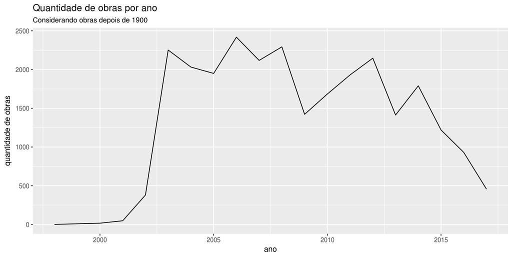

No total temos 28681 obras cadastradas, sendo 26056 delas a partir de 2003.

Como a maior parte das obras foi cadastradas a partir de 2003, consideraremos daqui em diante apenas as obras que tiveram início a partir deste ano.

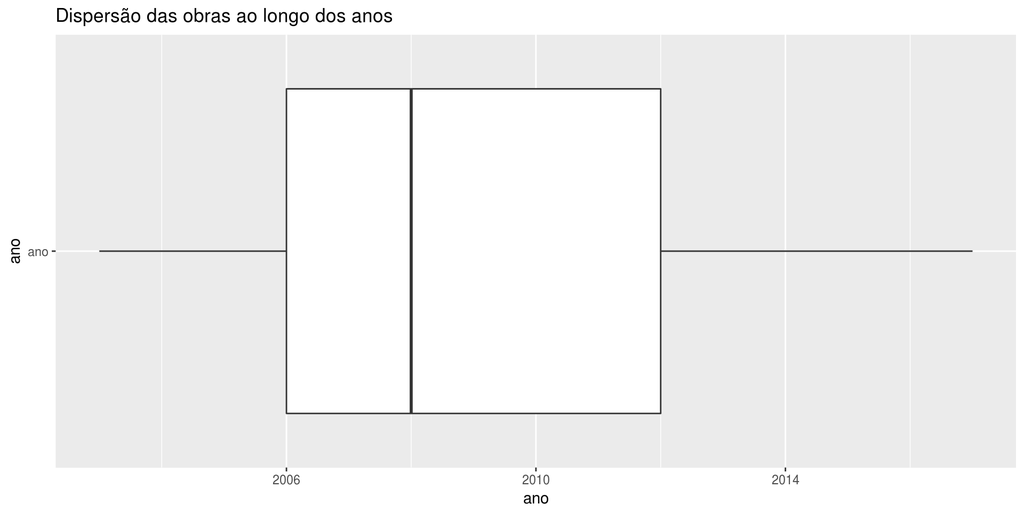

```r
obras.filtradas %>%
    ggplot(aes(x = "ano", y = ano)) +
        geom_boxplot() +
        coord_flip() +
        labs(x = "ano",
             title = "Dispersão das obras ao longo dos anos")
```

Vemos também que metade das obras foram construídas antes de 2008 e 25% das obras são datadas a partir de 2012. Todas obras possuem o município em que foram construída, além de possuir também a microregião e mesoregião que pertencem.

## Análise da geolocalização temporalmente

### Disponibilidade das geolocalizações temporalmente

Vejamos a existência dos dados georeferenciados temporalmente, onde a existência dos mesmos será indicada caso a geolocalização for do tipo 1 ou 3, visto que são os tipos cujos valores de geolocalização estão presentes na própria tabela, sendo um par de latitude e longitude, ou uma lista de pares. Não consideraremos os do tipo 2, que é uma referência para um arquivo .kml nem o tipo 0 que de fato é o valor inexistente.

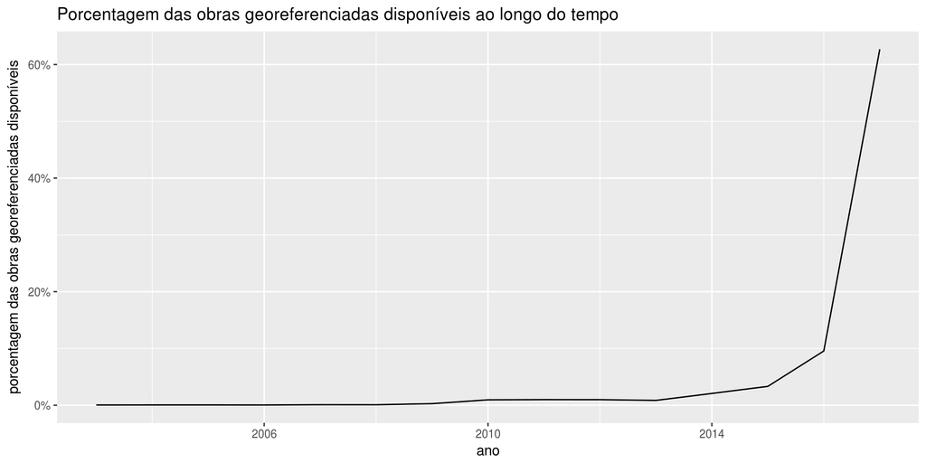

Analisando os dados de georeferenciamentos disponíveis, verificamos que existem alguns dados a partir de 2010, mas apenas no ano de 2017 existe um percentual razoável de dados geolocalizados, visto que chega a pouco mais de 62.70%.

Vejamos em números absoutos:

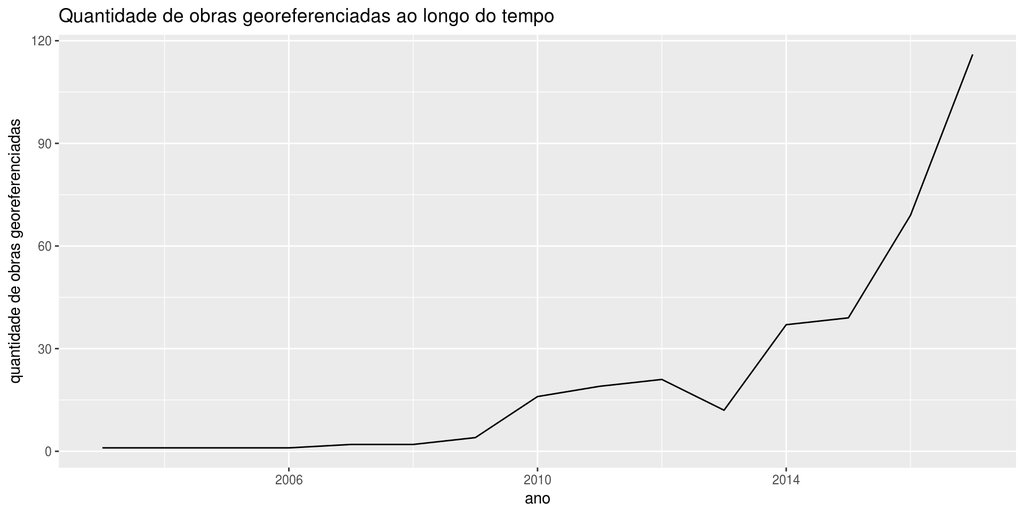

Podemos perceber que o número absoluto de obras geolocalizadas começa a crescer moderadamente a partir de 2010, mas tem uma ascensão mais forte a partir de 2015, chegando em 116 obras em 2017.

No total, existem 347 geolocalizadas.

### Análise dos tipos de geolocalização temporalmente

Vejamos se os tipos de geolocalização variaram ao longo do tempo:

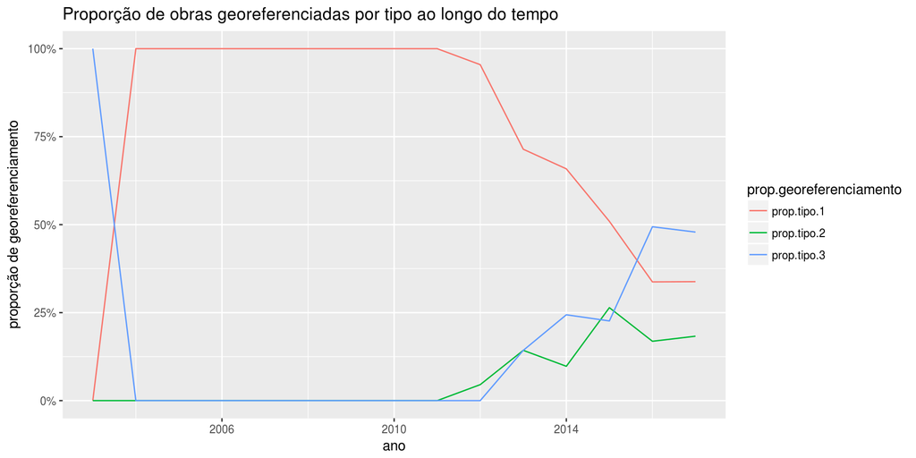

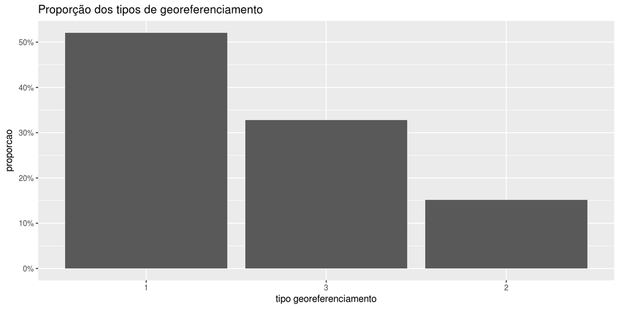

```r
obras.agrup.tipo.geo <- geolocalizacao %>%
    filter(tipo_georeferenciamento > 0) %>%
    mutate(total = n()) %>%
    group_by(tipo_georeferenciamento) %>%
    summarise(
        quantidade = n(),
        proporcao = quantidade / min(total)
    )

obras.agrup.tipo.geo %>%
    ggplot(aes(x = reorder(tipo_georeferenciamento, -proporcao), y = proporcao)) +
        geom_bar(stat = "identity") +
        scale_y_continuous(label = scales::percent) +
        labs(x = "tipo georeferenciamento",
             title = "Proporção dos tipos de georeferenciamento")
```

Vemos que pouco mais de 50% dos dados utilizam no georeferenciamento o tipo 1, pouco mais de 30% utilizam o tipo 3 e cerca de 15% utiliza o tipo 2.

**NOTA**: O tipo 1 é uma lista de pares latitude e longitude, o tipo 2 é uma referência para um arquivo KML e o tipo 3 é apenas um par de latitude e longitude.

## Análise do valor das obras temporalmente

### Valor da obra disponível

Vejamos primeiramente os dados disponíveis por época:

| id | data_inicio_obra | valor_obra | descricao_sucinta_obra | ano |
| --- | --- | --- | --- | --- |
| 8099 | 2013-02-01 | 0.01 | REFORMA DO POSTO MEDICO ESPEDIÃO CAETANO LEITE | 2013 |
| 8136 | 2013-04-01 | 0.01 | CONSTRUÇÃO E REFORMA DE MATA BURROS | 2013 |
| 8145 | 2013-04-24 | 0.01 | RECUPERAÇÃO DE ESOLAS MUNICIPAIS, CACIMBAS, SERRA BRANCA, CURTUME DESTE MUNICIPIO | 2013 |
| 9804 | 2013-05-01 | 0.01 | MANUTENÇÃO E CONSERVAÇÃO DE ESTRADAS VICINAIS | 2013 |
| 9831 | 2013-04-01 | 0.01 | CONSTRUÇÃO DE UMA BARRAGEM DE TERRA | 2013 |
| 12474 | 2013-07-10 | 0.01 | serrviços de recuperação de calçamento e meio fio da rua São João nesta cidade. | 2013 |

|  | id | data_inicio_obra | valor_obra | descricao_sucinta_obra | ano |
| --- | --- | --- | --- | --- | --- |
| 508 | 8904 | 2013-04-26 | 950.00 | serviços prestados de empreitada na construção de 02 barragens subterrâneas, no leito do riacho do sítio lagoa da ilha, zona rural desse município. | 2013 |
| 509 | 11492 | 2014-05-02 | 967.16 | PRESTAÇÃO DE SERVIÇOS DE MÃO DE OBRA NA RECUPERAÇÃO DO PAVIMENTO DO TERMINAL RODOVIARIO MUNCIPAL, SENDO REPOISÇÃO DE PAVIMENTO EM PARALELEPIPEDO SOBRE COLCHÃO DE AREIA REJUNTADO COM EMULSÃO ASFALTICA … | 2014 |
| 510 | 10128 | 2013-02-04 | 1000.00 | REFORMA DE ESCOLA | 2013 |
| 511 | 14634 | 2015-08-03 | 1000.00 | SERVICO DE LIMPEZA NOS POCOS QUE PERTENCEM AO SISTEMA DE ABASTECIMENTO DE AGUA DESTE MUNICIPIO. | 2015 |
| 512 | 14636 | 2015-08-03 | 1000.00 | PRESTACAO DE SERVICOS DE AJUDANTE OPERADOR DE MAQUINAS PESADAS, PARA ATENDER A NECESSIDADE TEMPORARIA NOS SERVICOS DE RECUPERACAO DE ESTRADAS VICINAIS DESTE MUNICIPIO. | 2015 |
| 513 | 19924 | 2013-08-27 | 1000.00 | SERVIÇOS DE 100 CARRADAS DE AREIA COMO CONTRA PARTIDA DESTA PREFEITURA PARA CONSTRUÇÃO DE CISTERNAS DE PLACAS GERENCIADAS PELO CISCO. | 2013 |

É possível ver que existem várias obras com valores maior que zero, mas mesmo assim não condizem com o valor real de uma obra. Com isso, vamos considerar como valor válido obras com mais de 1000 reais.

Vejamos a proporção de obras com valores válidos:

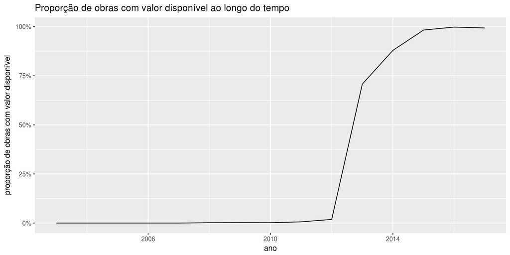

Vemos que os dados do valor da obra começaram a ser colocados apenas em 2013 e quase todas obras tem valor a partir de 2015.

Vejamos em números absolutos:

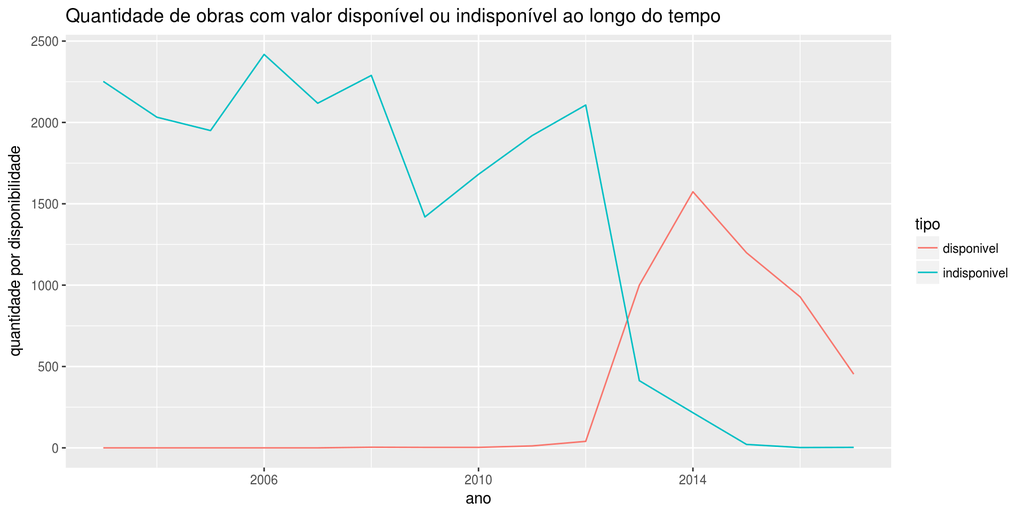

Vemos que grande parte das obras que tem valor foram iniciadas entre 2013 e 2015, enquanto as obras sem valor disponível foran iniciadas antes de 2013, ou seja, o campo valor da obra começou a ser preenchido a partir de 2013.

### Análise do valor das obras temporalmente

Vejamos se os valores das obras vem aumentando desde 2013, ano que estas começaram a ser preenchidas com vigor:

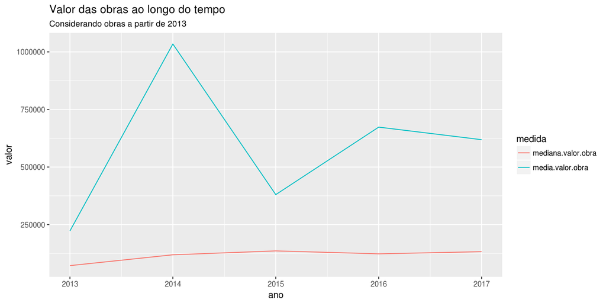

Vemos que a mediana dos valores fica um pouco acima dos 100 mil reais, mas existe alguns outliers que elevam a média consideravelmente, criando uma grande diferença entre a média e a mediana.

Vejamos a dispersão do valor das obras ao longo do tempo:

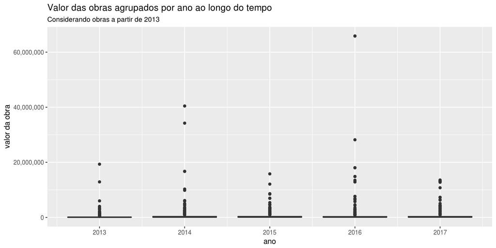

Como comentado anteriormente, os valores das obras são bem concentrados, mas existem alguns outliers que elevam a média.

## Dimensão das obras temporalmente

### Dimensão da obra disponível

Vejamos primeiramente qual a medida de dimensão utilizada.

| id | data_inicio_obra | dimensao | descricao_sucinta_obra | ano |
| --- | --- | --- | --- | --- |
| 53 | 2016-10-14 | 36.00 | Perfuração de poço de sedimento com 36 m de profundidade no PSF Planalto | 2016 |
| 28316 | 2017-04-21 | 0.25 | EXECUÇÃO DE OBRA DE CONSTRUÇÃO DE REDE ELETRICA DE A.T. PARA ATENDER COM ENERGIA E IMPLANTAÇÃO DE 250M DE REDE ELETRICA TRIFÁSICA ALTA TENSÃO E SUBSTAÇÃO DE 30 KVA COM QUADRO DE MEDIÇÃO TRIFÁSICO ,PAR… | 2017 |
| 28482 | 2017-07-10 | 105.00 | CONSTRUÇÃO SIMPLIFICADA DE UM PAVILHÃO ABERTO COM COBERTA EM MADEIRA E TELHA DE AMIANTO, PILARES EM TUBO DE PVC COM CONCRETO, SANITARIOS MASCULINO E FEMININO COM AREA DE CONSTRUÇÃO DE 105,00M², NA ALD… | 2017 |

Podemos ver primeiramente que a dimensão de algumas obras estão representadas em medidas diferentes, onde umas representam a dimensão em metros, outras representam em quilômetros, enquando outras representam em metros quadrados, o que torna difícil indicar quais dimensões com valor maior que zero são inválidas. Com isso consideraremos dimensões disponívels apenas as que tiverem valor maior que zero.

Vejamos a proporção de dados de dimensão disponíveis temporalmente:

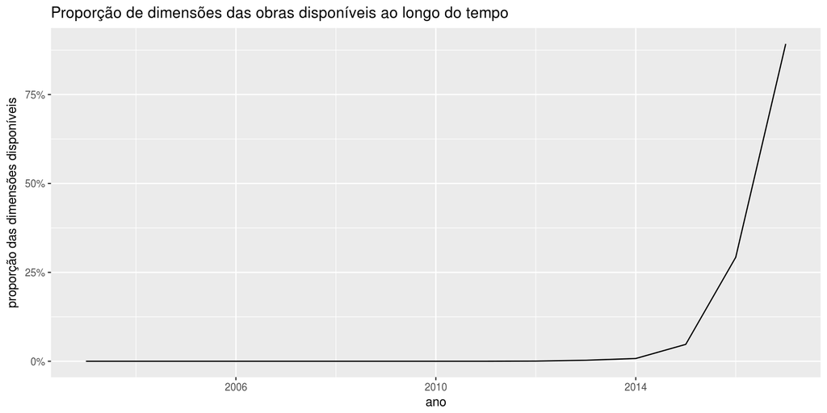

Vemos que os dados de dimensões começaram a ser implantados em 2015, mas só atingiram uma proporção considerável de dimensões válidas em 2017.

Vejamos em valores absolutos:

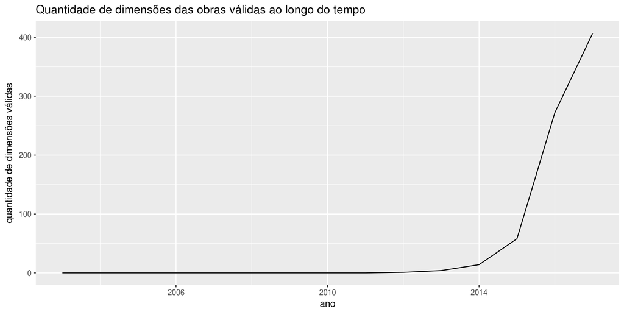

Os valores absolutos seguem a mesma tendência dos proporcionais. No total temos 756 obras com dimensões válidas.

### Dimensão da obra temporalmente

Vejamos quanto o valor das dimensões válidas variam no decorrer do tempo.

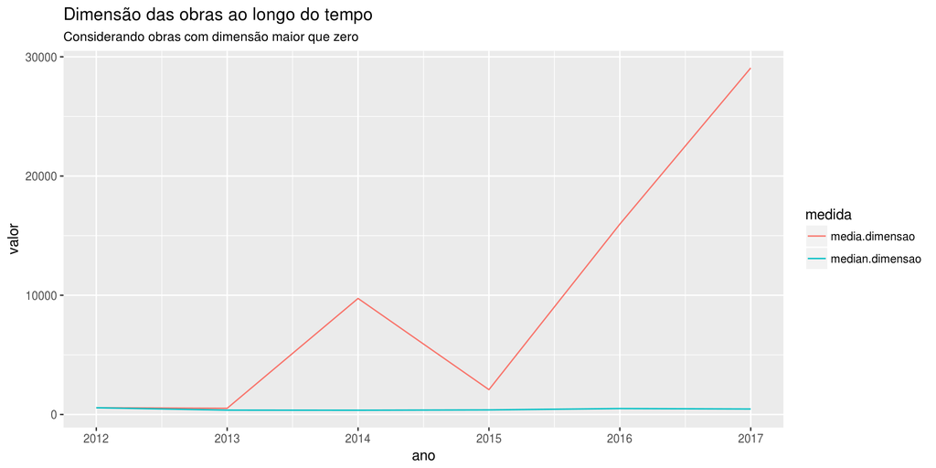

Vemos que a mediana se mantém quase constante ao longo do tempo, tendo valor perto dos 400, enquanto a média varia bastante, o que indica que existem outliers nas dimensões das obras, como podemos ver a seguir:

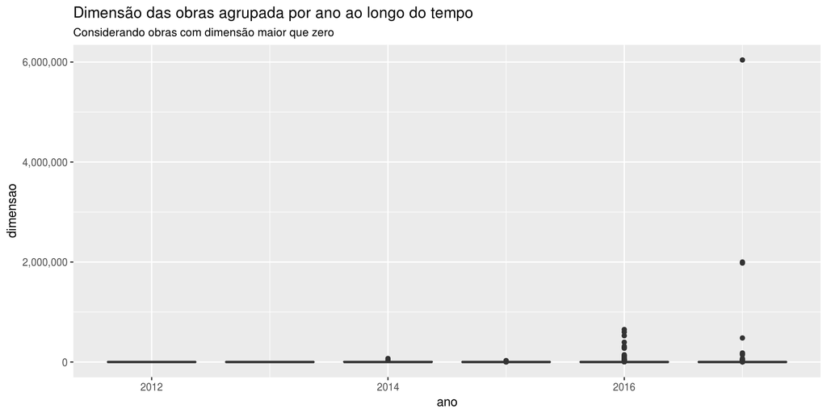

## Tipo da obra temporalmente

### Disponibilidade de dados

Vejamos os tipos da obra disponíveis

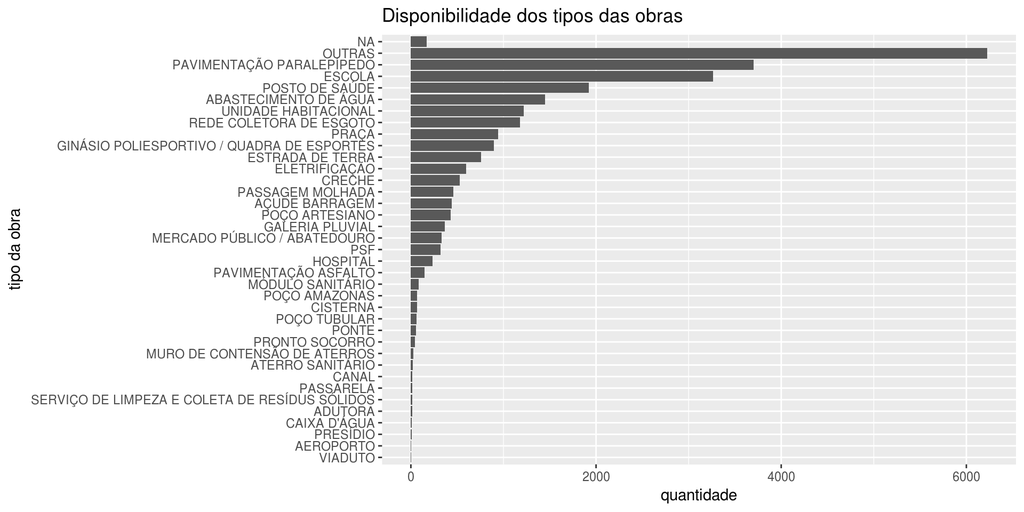

Vemos que o tipo de obra mais presente nos dados é o tipo “outras”, seguido de “pavimentação paralelepípedo” e “escola”. Vemos que existem uma pequena quantidade de dados faltantes.

Vejamos se os dados disponíveis são mais recentes, ou o período é irrelevante:

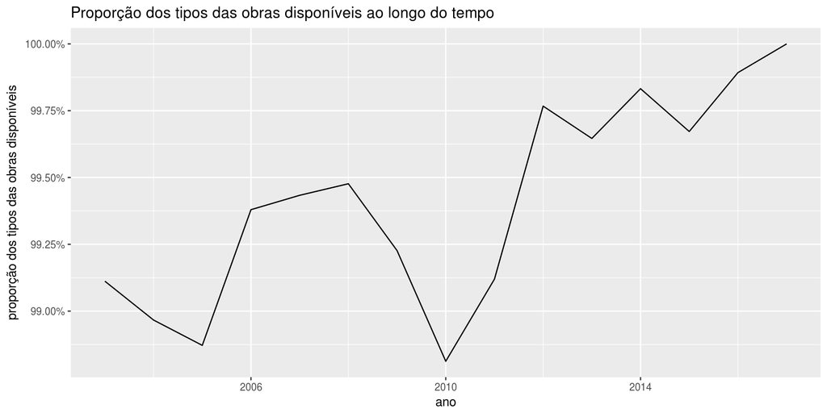

Vemos que a disponibilidade dos dados do tipo da obra cresceram ao longo do tempo, apesar de que, em todo período analisado, os tipos das obras tem uma boa disponibilidade de dados, se mantendo sempre acima de 98,5%.

### Análise temporal

Vejamos quais os tipos de obra que vem sendo mais construídos ao longo do tempo:

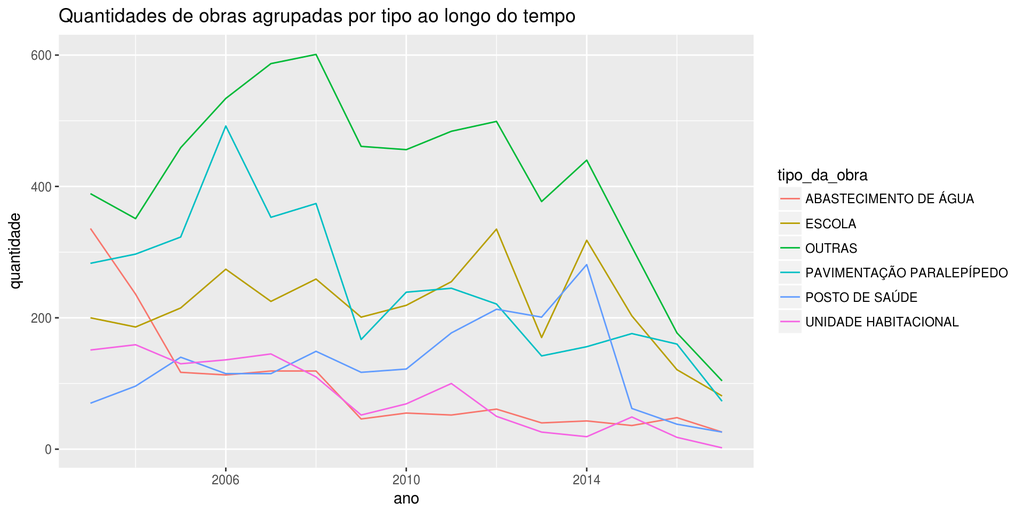

Podemos ver que dos seis tipos de obras mais construídas, a escolas e postos de saúdes são as únicos que tem uma tendência crescente até 2014, após isso todos tipos de obras tendem a cair.

## Nome do jurisdicionado temporalmente

### Nome do jurisdicionado disponível

Vemos pelo gráfico abaixo que 100% das obras possuem o nome do jurisdicionado responsável.

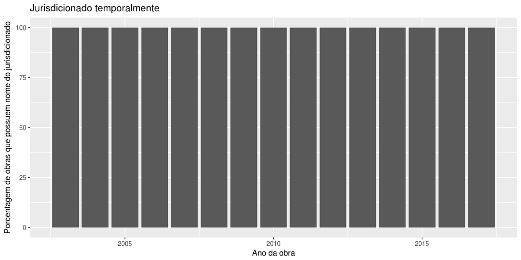

### Quantidade de obras por jurisdicionado

No gráfico abaixo podemos ver quais jurisdicionados possuem a maior quantidade de obras. Algumas prefeituras de cidades tidas como pequenas aparecem no ranking enquanto orgãos de cidades maiores como Patos e Souza não aparecem.

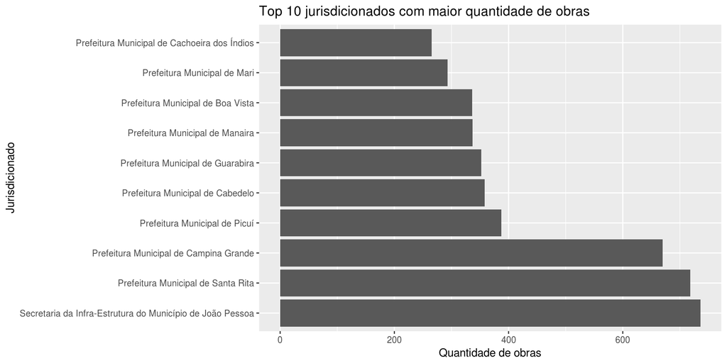